# Retail Sales - Time Series Forecasting

Nandhini Sureshkumar

2025-05-16

## Data Description

For this project, I analyzed US retail sales data to explore recent trends and build forecasting models using time series techniques. The datasets were sourced from the Federal Reserve Economic Data (FRED) platform, covering multiple retail sectors from 2000 to 2024. I focused on the following retail categories:

- Retail Trade and Food Services
- Clothing and Accessories Stores
- Furniture and Home Furnishings Stores

Additional variables used to enrich the analysis include:

- Consumer Price Index (CPI) from FRED, representing inflationary pressure

Google Trends search interest for:

- “restaurants” (for food services)
- “clothing” (for apparel and accessories)
- “furnish” (for furniture and furnishings)

These external signals were joined to assess whether macroeconomic trends and consumer online behavior correlate with retail performance across different sectors.

## Research Objective

The main goal of this project is to understand and forecast retail sales behavior in the US. Specifically, I ask:

- How well can we model and forecast sales for different retail sectors such as food services, clothing, and furniture?
- Do external indicators like CPI or Google Trends improve forecasting accuracy, and does their impact vary by category?
- Which models (ARIMA, ETS, TSLM with Fourier terms, or ARIMA with external regressors) deliver the most accurate forecasts for each retail segment?
- This multi-sectoral approach allows us to identify whether modeling strategies need to be customized based on the nature of the retail category.

## Data Extraction & Data Cleaning

To begin the analysis, I collected monthly retail sales data from the Federal Reserve Economic Data (FRED) platform. This included key retail sectors: Food Services, Clothing, and Furniture. Additionally, I incorporated the Consumer Price Index (CPI) to account for inflation and Google Trends data to reflect real-time consumer interest.

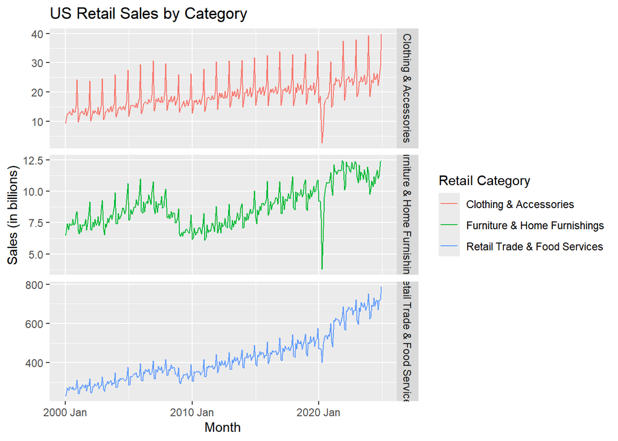

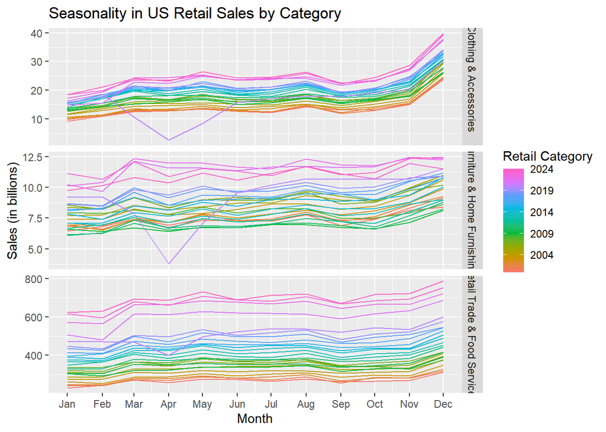

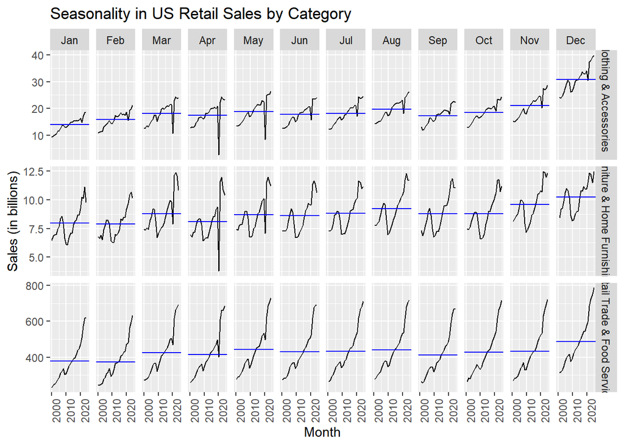

## Visualizations and Decomposition

### Retail Trade and Food Services

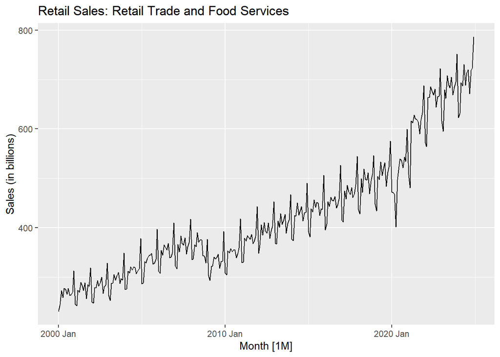

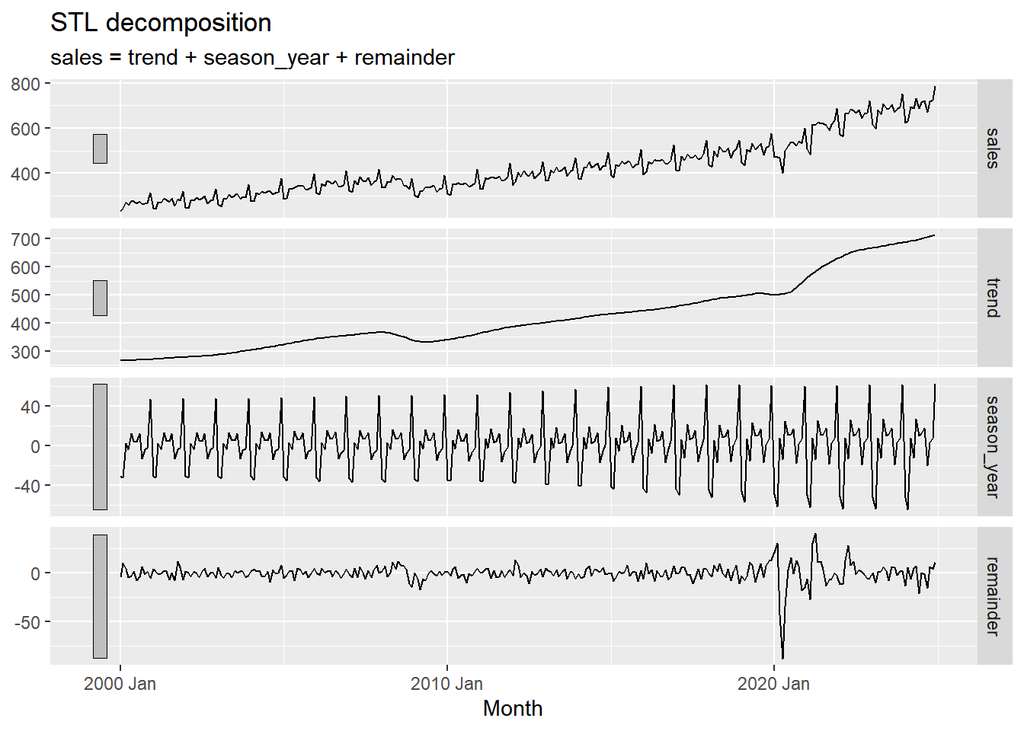

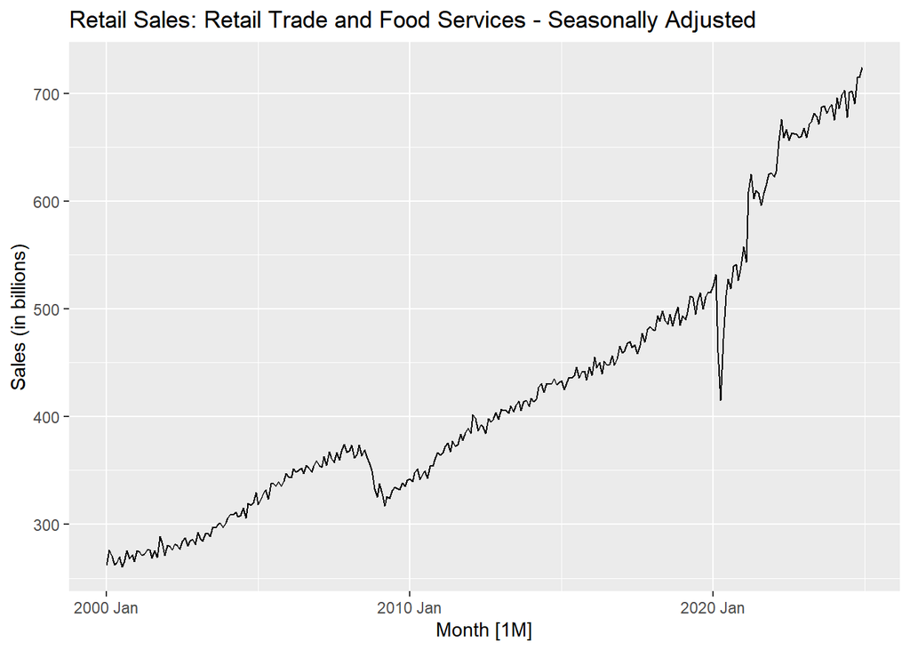

#### Differeneced Data For Stationarity

This section will discuss the auto-correlation, and partial auto-correlation function plots (ACF/PACF), these plots allowed for the estimation of our performed forecasts.

#### First Difference (Full-Sample)

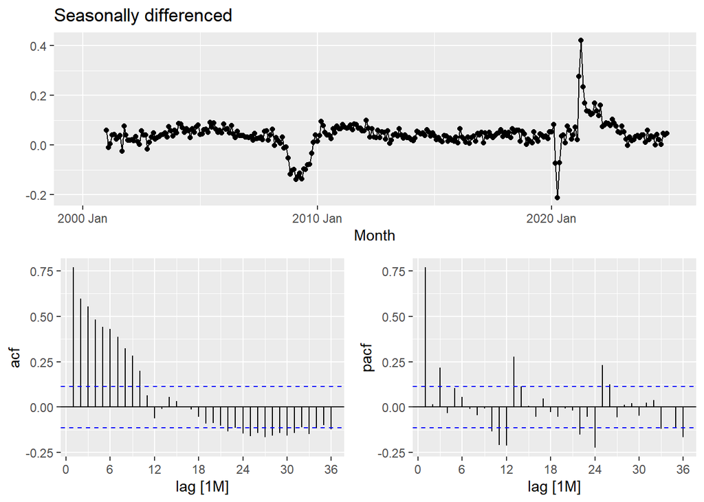

These are also clearly non-stationary, so we take a further first difference

#### Double Difference (Full-Sample)

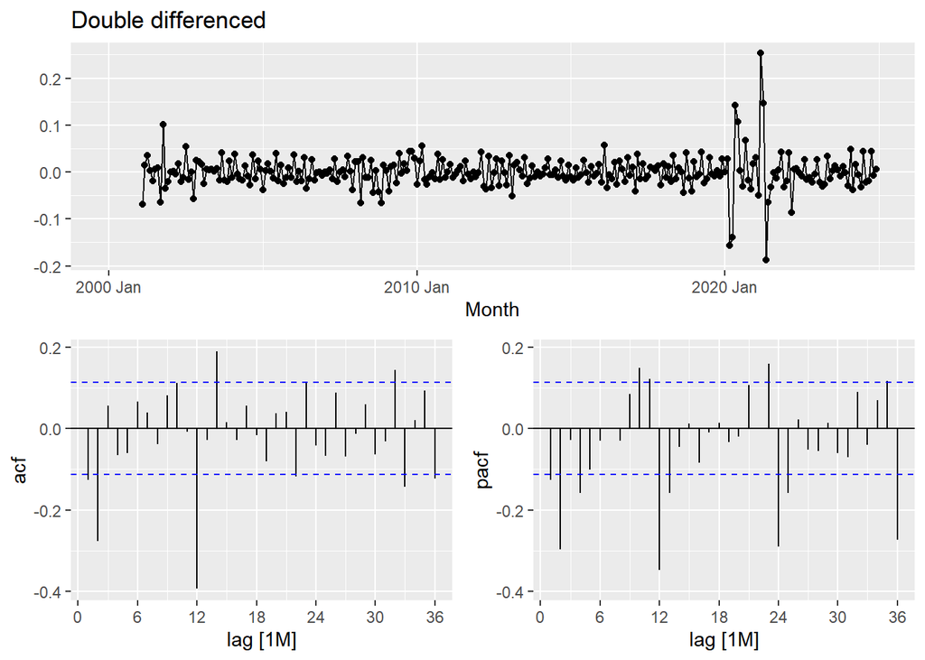

The appropriate ARIMA model based on the ACF and PACF:

First Model : ARIMA(0,1,2)(0,1,1)12

- The significant spike at lag 2 in the ACF suggests a non-seasonal MA(2) component.
- The significant spike at lag 12 in the ACF suggests a seasonal MA(1) component.
- So, we begin with an ARIMA(0,1,2)(0,1,1)12 model, indicating a first difference, a seasonal difference, and non-seasonal MA(2) and seasonal MA(1) component.

Second Model : ARIMA(2,1,0)(0,1,1)12

- With PACF, we may have an ARIMA(2,1,0)(0,1,1) 12 model — using the PACF to select the non-seasonal part of the model and the ACF to select the seasonal part of the model.

Third Model : ARIMA(2,1,0)(1,1,0)12

- The significant spike at lag 2 in the PACF suggests a non-seasonal AR(2) component.
- The significant spike at lag 12 in the ACF suggests a seasonal AR(1) component.
- So, an ARIMA(2,1,0)(1,1,0)12 model, indicating a first difference, a seasonal difference, and non-seasonal AR(2) and seasonal AR(1) component.

### Clothing and Clothing Accessory Stores

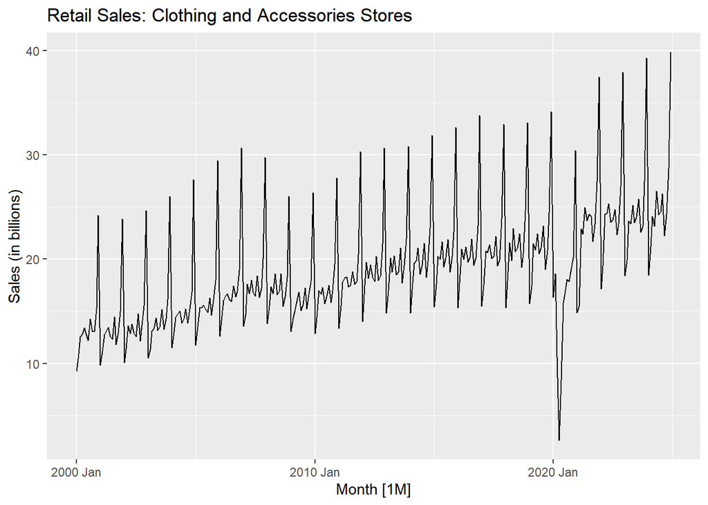

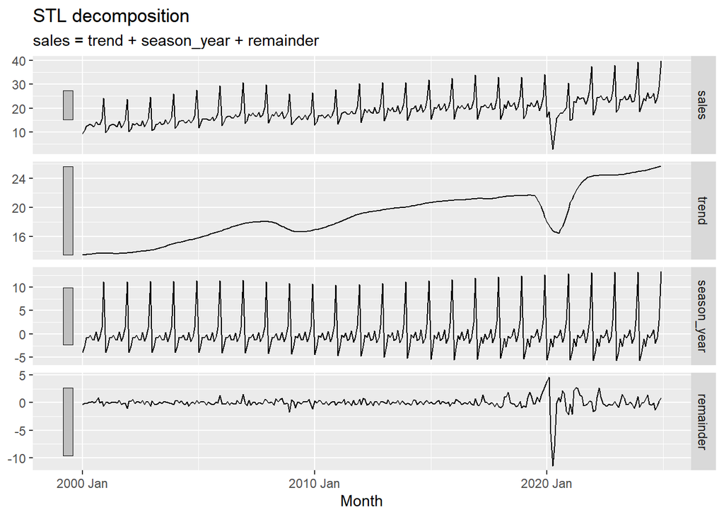

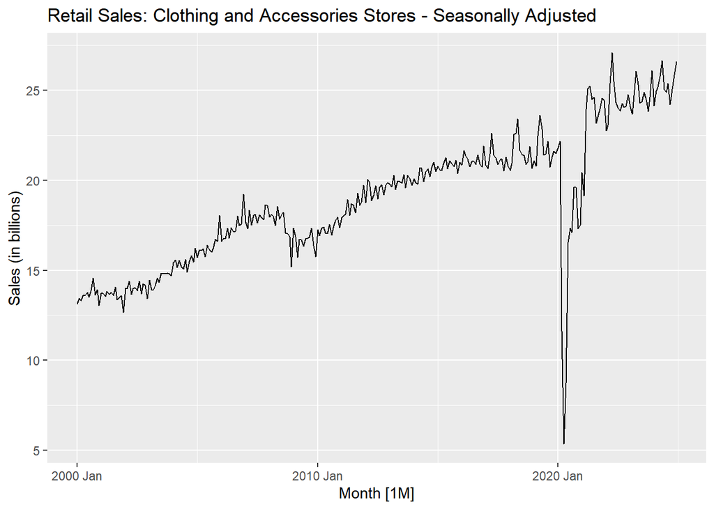

#### Differeneced Data For Stationarity

This section will discuss the auto-correlation, and partial auto-correlation function plots (ACF/PACF), these plots allowed for the estimation of our performed forecasts.

#### First Difference (Full-Sample)

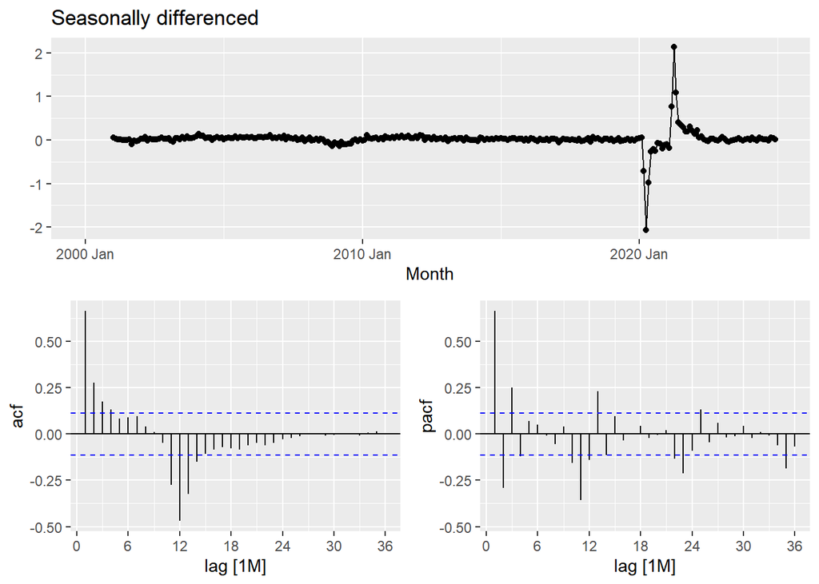

These are also clearly non-stationary, so we take a further first difference

#### Double Difference (Full-Sample)

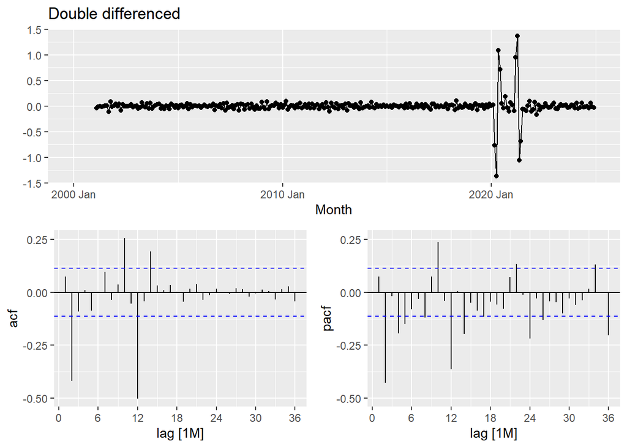

The appropriate ARIMA model based on the ACF and PACF:

First Model : ARIMA(0,1,2)(0,1,1)12

- The significant spike at lag 2 in the ACF suggests a non-seasonal MA(2) component.
- The significant spike at lag 12 in the ACF suggests a seasonal MA(1) component.
- So, we begin with an ARIMA(0,1,2)(0,1,1)12 model, indicating a first difference, a seasonal difference, and non-seasonal MA(2) and seasonal MA(1) component.

Second Model : ARIMA(2,1,0)(0,1,1)12

- With PACF, we may have an ARIMA(2,1,0)(0,1,1) 12 model — using the PACF to select the non-seasonal part of the model and the ACF to select the seasonal part of the model.

Third Model : ARIMA(2,1,0)(1,1,0)12

- The significant spike at lag 2 in the PACF suggests a non-seasonal AR(2) component.
- The significant spike at lag 12 in the ACF suggests a seasonal AR(1) component.
- So, an ARIMA(2,1,0)(1,1,0)12 model, indicating a first difference, a seasonal difference, and non-seasonal AR(2) and seasonal AR(1) component.

### Furniture and Home Furnishings Stores

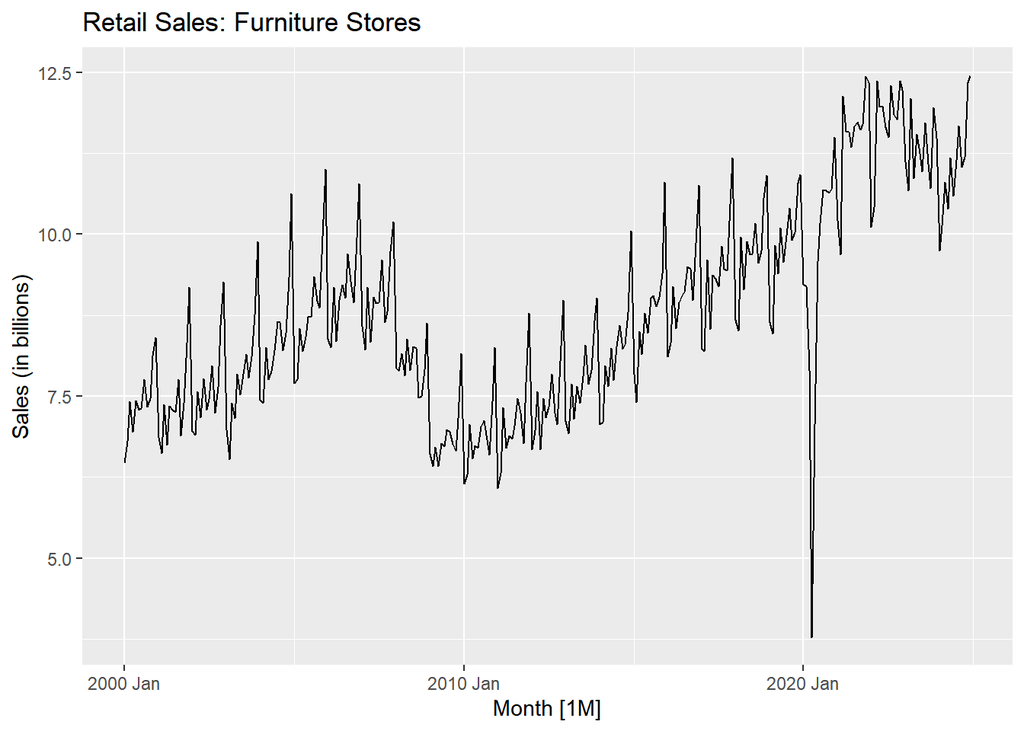

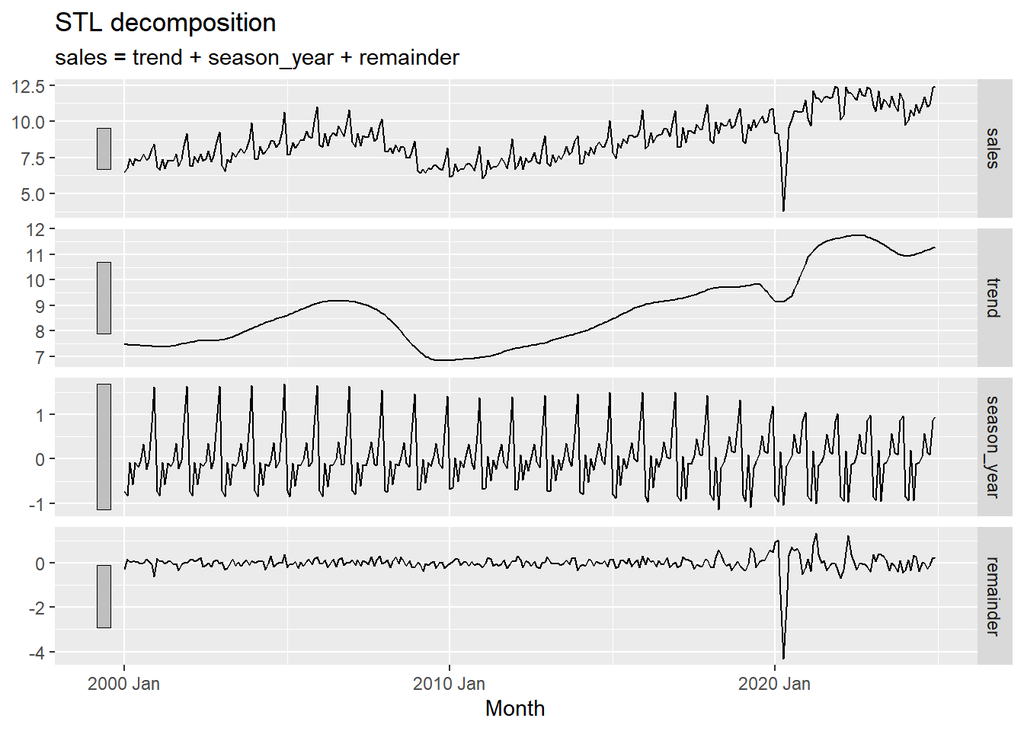

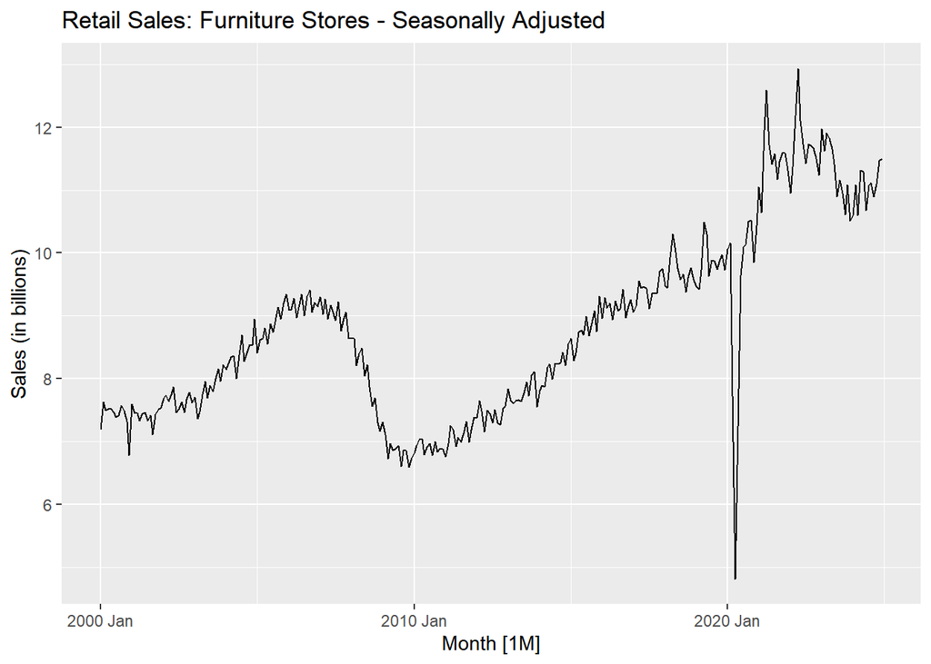

#### Differeneced Data For Stationarity

This section will discuss the auto-correlation, and partial auto-correlation function plots (ACF/PACF), these plots allowed for the estimation of our performed forecasts.

#### First Difference (Full-Sample)

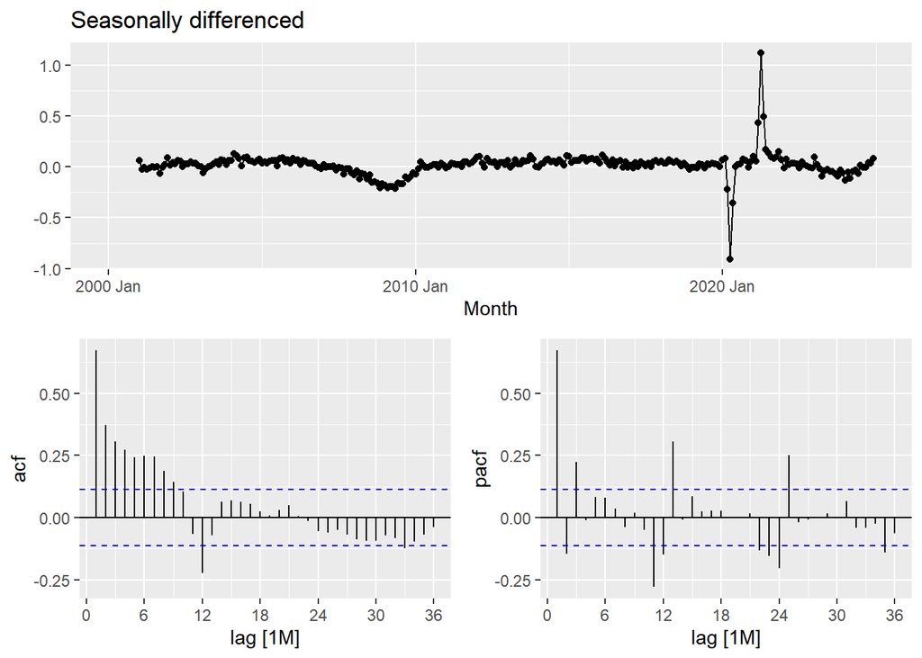

These are also clearly non-stationary, so we take a further first difference

#### Double Difference (Full-Sample)

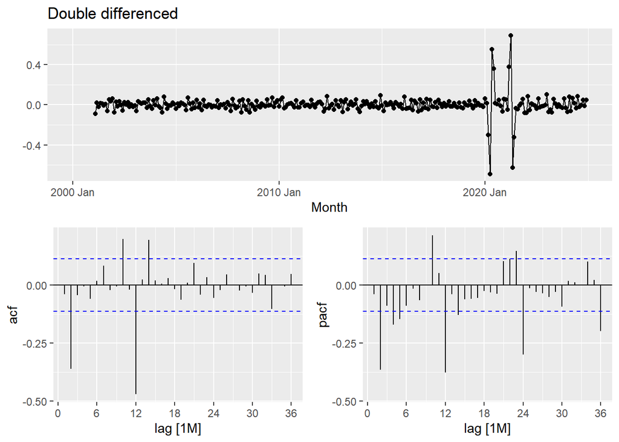

The appropriate ARIMA model based on the ACF and PACF:

First Model : ARIMA(0,1,2)(0,1,1)12

- The significant spike at lag 2 in the ACF suggests a non-seasonal MA(2) component.
- The significant spike at lag 12 in the ACF suggests a seasonal MA(1) component.
- So, we begin with an ARIMA(0,1,2)(0,1,1)12 model, indicating a first difference, a seasonal difference, and non-seasonal MA(2) and seasonal MA(1) component.

Second Model : ARIMA(2,1,0)(0,1,1)12

- With PACF, we may have an ARIMA(2,1,0)(0,1,1) 12 model — using the PACF to select the non-seasonal part of the model and the ACF to select the seasonal part of the model.

Third Model : ARIMA(2,1,0)(1,1,0)12

- The significant spike at lag 2 in the PACF suggests a non-seasonal AR(2) component.
- The significant spike at lag 12 in the ACF suggests a seasonal AR(1) component.
- So, an ARIMA(2,1,0)(1,1,0)12 model, indicating a first difference, a seasonal difference, and non-seasonal AR(2) and seasonal AR(1) component.

## Model Building

### Retail Trade and Food Services

#### Train - Test Split

I split the dataset into training and test sets. All data before January 2022 was used for training, while data from January 2022 onwards was reserved for testing. This setup allows for an honest evaluation of the forecasting models’ ability to generalize.

I also visualized the training data across the three variables to observe any discrepancies in trends and seasonality, which helped validate the relationships among these features before fitting time series models.

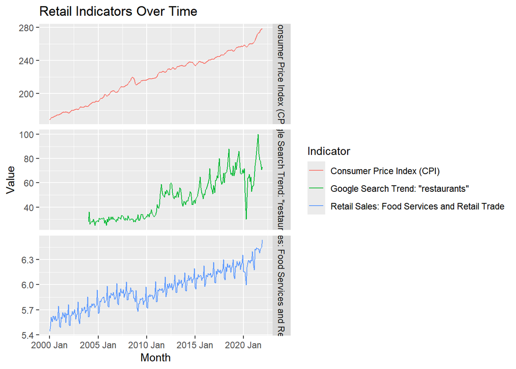

Google Trends for “restaurants” spikes notably after 2015, peaking around 2021, then fluctuating—likely impacted by pandemic recovery patterns and changing consumer behaviors very similar to sales.

Retail Sales exhibit strong seasonality with an upward trend, sharply rising after pandemic.

#### Model Fitting

```
# A mable: 10 x 2
# Key:     Model name [10]
   `Model name`                                   Orders
   <chr>                                         <model>
 1 fourier6                                       <TSLM>
 2 ets                                      <ETS(M,A,A)>
 3 arima012011                 <ARIMA(0,1,2)(0,1,1)[12]>
 4 arima210011                 <ARIMA(2,1,0)(0,1,1)[12]>
 5 arima210110                 <ARIMA(2,1,0)(1,1,0)[12]>
 6 stepwise           <ARIMA(3,0,2)(0,1,1)[12] w/ drift>
 7 arima1             <ARIMA(3,0,0)(0,1,1)[12] w/ drift>
 8 arimax_cpi     <LM w/ ARIMA(3,0,0)(0,1,1)[12] errors>
 9 arimax_google             <LM w/ ARIMA(4,1,0) errors>
10 arima_fourier6            <LM w/ ARIMA(1,1,2) errors>
```

##### AIC Comparison

```
# A tibble: 10 × 6
   .model            sigma2 log_lik    AIC   AICc    BIC
   <chr>              <dbl>   <dbl>  <dbl>  <dbl>  <dbl>
 1 fourier6       0.00255      420. -1562. -1560. -1512.
 2 arima_fourier6 0.000703     589. -1146. -1144. -1089.
 3 arimax_cpi     0.000676     557. -1103. -1102. -1081.
 4 arima1         0.000745     544. -1077. -1076. -1056.
 5 stepwise       0.000750     545. -1074. -1073. -1046.
 6 arima012011    0.000754     540. -1071. -1071. -1057.
 7 arima210011    0.000761     539. -1069. -1069. -1055.
 8 arima210110    0.000962     514. -1020. -1020. -1006.
 9 arimax_google  0.00390      271.  -529.  -528.  -504.
10 ets            0.0000200    230.  -426.  -424.  -365.
```

I fitted multiple models including ARIMA variants, Fourier-based regression, ETS, and models with external regressors like CPI and Google Trends. Then I compared them using AICc to find the best fit.

From the table, fourier6 emerged as the best model with the lowest AICc (-1560), demonstrating that incorporating Fourier terms significantly enhanced forecasting accuracy.

The arima_fourier6 model also performed well with an AICc of -1144, outperforming most ARIMA setups but still behind the pure Fourier model.

arimax_cpi showed moderate predictive strength with an AICc of -1102, indicating that CPI provided some added value but was not as effective as the Fourier terms.

ETS had the highest AICc (-424), indicating poor fit, likely due to its limitations in capturing complex seasonal patterns.

###### Forecasts: Top 6 Models Ranked by AICc

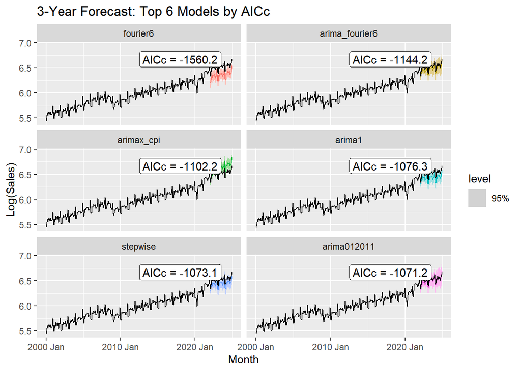

##### Training Data RMSE

```
# A tibble: 10 × 5
   .model         .type      RMSE    MAE  MAPE
   <chr>          <chr>     <dbl>  <dbl> <dbl>
 1 arimax_cpi     Training 0.0251 0.0171 0.285
 2 arima_fourier6 Training 0.0257 0.0173 0.290
 3 ets            Training 0.0263 0.0170 0.284
 4 stepwise       Training 0.0264 0.0177 0.297
 5 arima1         Training 0.0264 0.0178 0.298
 6 arima012011    Training 0.0266 0.0178 0.297
 7 arima210011    Training 0.0267 0.0178 0.297
 8 arima210110    Training 0.0301 0.0209 0.349
 9 fourier6       Training 0.0492 0.0354 0.595
10 arimax_google  Training 0.0681 0.0509 0.848
```

I evaluated all models based on training RMSE to assess their fit to the historical data.

arimax_cpi performed the best with the lowest RMSE of 0.0251, closely followed by arima_fourier6 (0.0257) and ETS (0.0263). This indicates that CPI is a strong predictor, slightly outperforming Fourier-enhanced ARIMA and ETS.

The basic ARIMA models (arima012011, arima210011, arima210110) showed slightly higher RMSEs, suggesting that external regressors like CPI provide additional predictive power.

Fourier6 had a relatively higher RMSE of 0.0492, indicating that seasonality alone wasn’t sufficient to capture the data patterns effectively.

arimax_google had the highest RMSE (0.0681), suggesting that Google Trends was less effective in this context compared to CPI.

Overall, models incorporating CPI and Fourier terms showed the best fit, highlighting their utility in capturing key patterns in the data.

###### Forecasts: Top 6 Models Ranked by Training Data RMSE

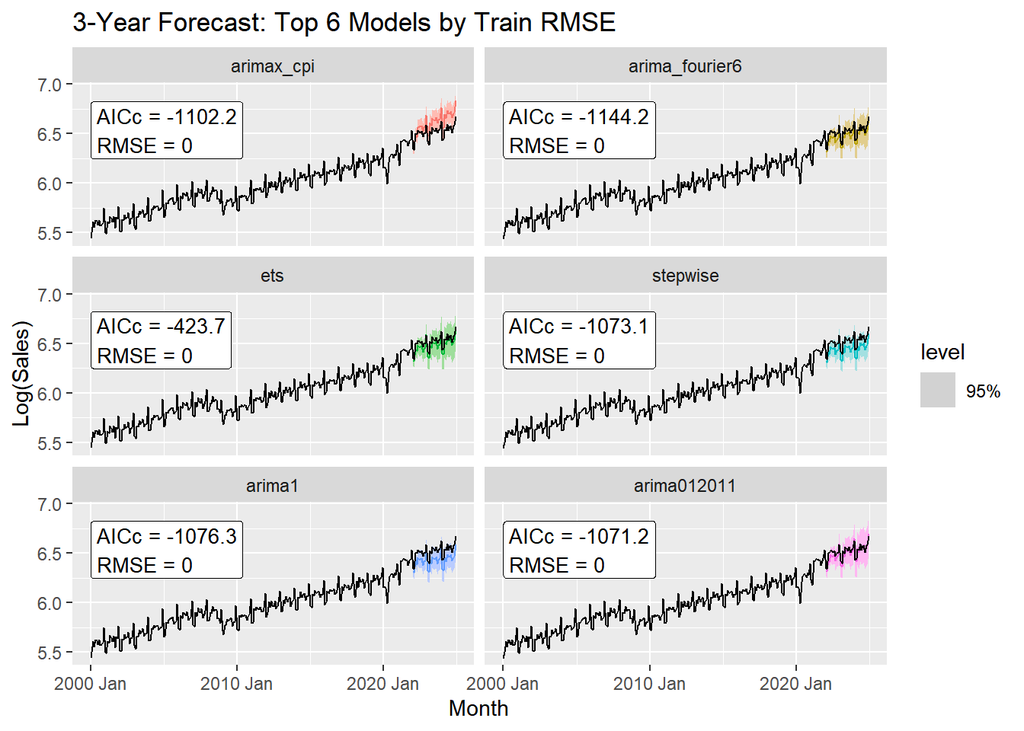

##### Test Data RMSE

```
# A tibble: 10 × 5
   .model         .type   RMSE    MAE  MAPE
   <chr>          <chr>  <dbl>  <dbl> <dbl>
 1 arima210011    Test  0.0306 0.0255 0.392
 2 arima012011    Test  0.0310 0.0261 0.401
 3 arima_fourier6 Test  0.0434 0.0394 0.605
 4 ets            Test  0.0446 0.0408 0.627
 5 arimax_google  Test  0.0655 0.0521 0.798
 6 stepwise       Test  0.0776 0.0752 1.15
 7 arima1         Test  0.0904 0.0877 1.35
 8 arima210110    Test  0.0923 0.0749 1.14
 9 arimax_cpi     Test  0.104  0.0946 1.45
10 fourier6       Test  0.159  0.158  2.42
```

I evaluated model performance on the test set (2022–2024) using RMSE.

###### Forecasts: Top 6 Models Ranked by Test Data RMSE

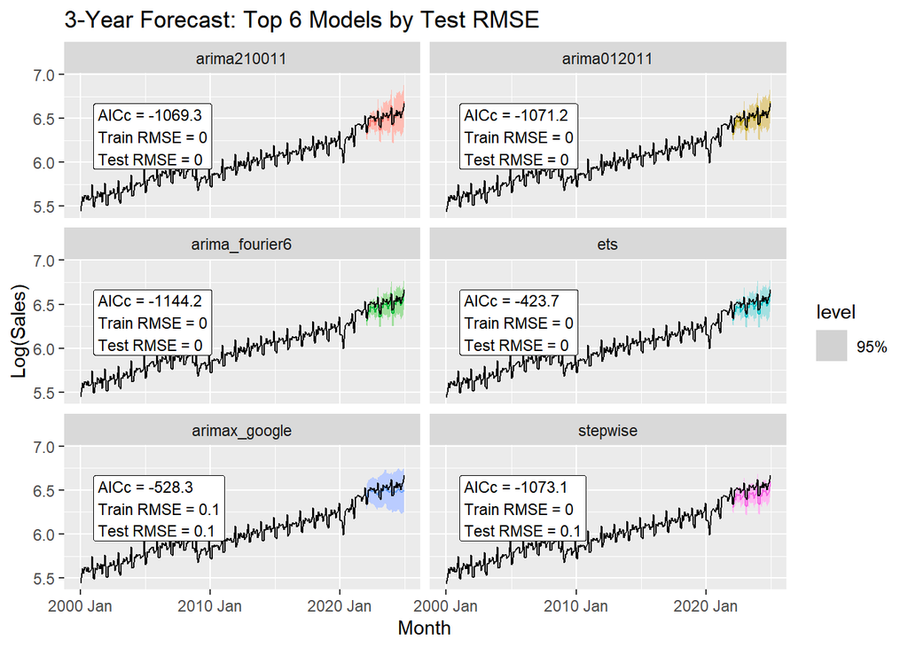

I evaluated model performance on the test set (2022–2024) using RMSE.

arima210011 performed best with the lowest RMSE of 0.0306, indicating strong generalization to test data. arima012011 followed closely with an RMSE of 0.0310, reinforcing the effectiveness of standard ARIMA setups.

arima_fourier6 and ETS performed reasonably well with RMSEs of 0.0434 and 0.0446, showing that seasonality and ETS components still provided useful predictive power.

Overall, standard ARIMA models (arima210011, arima012011) demonstrated the best predictive accuracy, while external signals like Google Trends and CPI did not generalize as effectively to the test set.

#### Evaluation of ARIMA Models

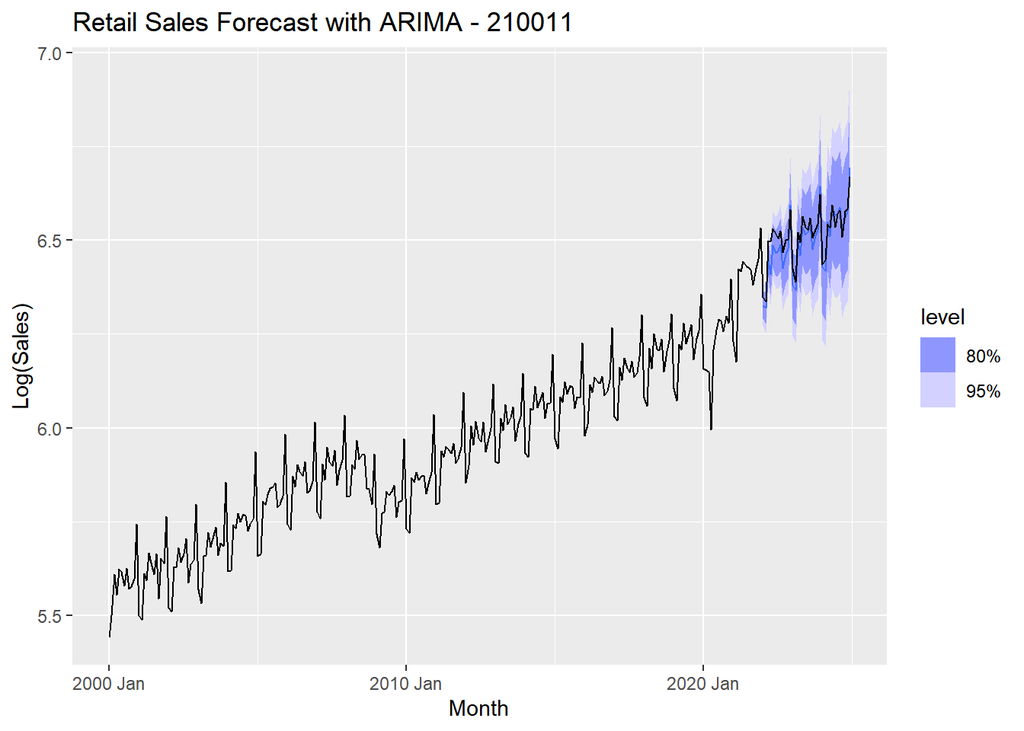

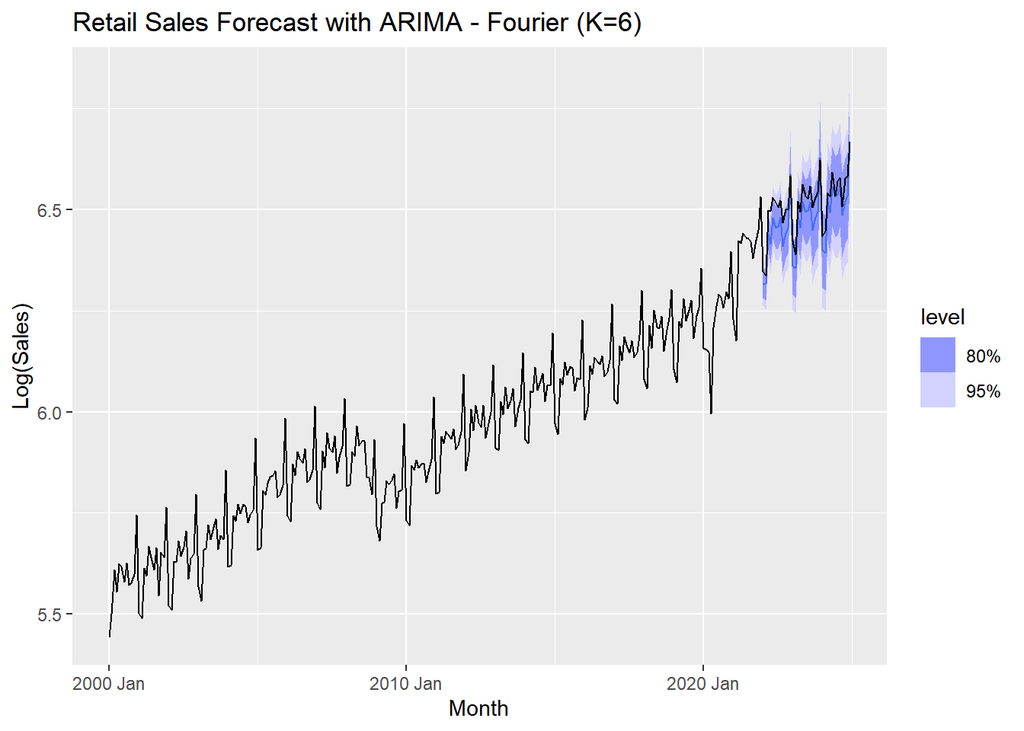

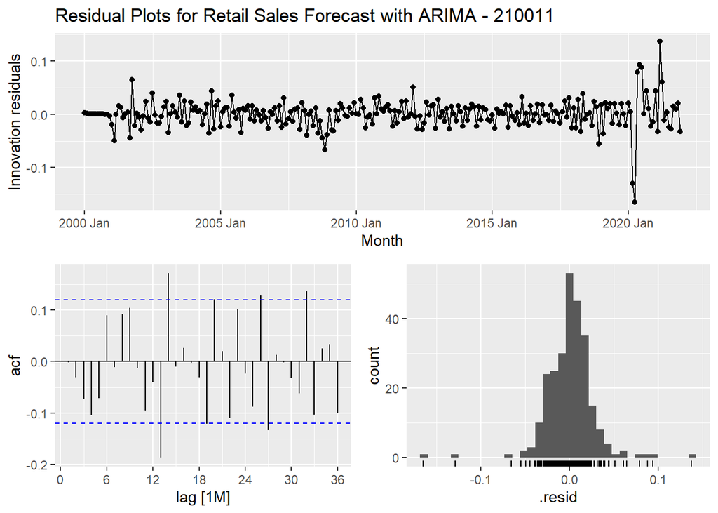

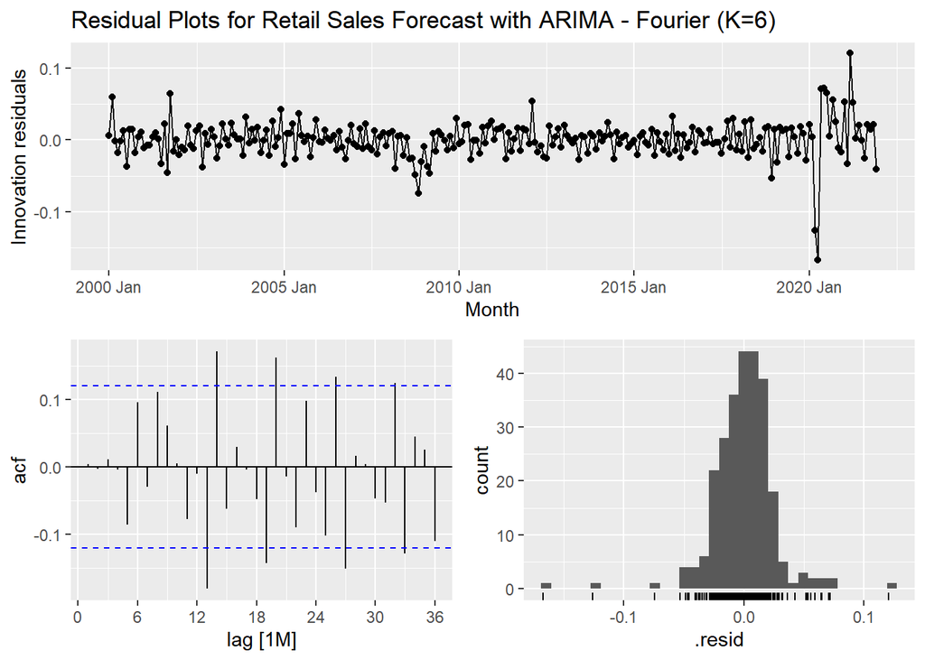

```
# A tibble: 4 × 5
  .model         .type      RMSE    MAE  MAPE
  <chr>          <chr>     <dbl>  <dbl> <dbl>
1 arima210011    Training 0.0267 0.0178 0.297
2 arima_fourier6 Training 0.0257 0.0173 0.290
3 arima210011    Test     0.0306 0.0255 0.392
4 arima_fourier6 Test     0.0434 0.0394 0.605
```

```
# A tibble: 2 × 3
  .model         lb_stat lb_pvalue
  <chr>            <dbl>     <dbl>
1 arima210011      10.5      0.229
2 arima_fourier6    8.17     0.147
```

Both models passed key residual diagnostics:

- Residuals from arima210011 show minor fluctuations but remain centered around zero, while arima_fourier6 exhibit a more structured pattern but still maintain mean zero — both indicating a good model fit.
- Autocorrelation (ACF) plots show most spikes within the 95% confidence bounds, suggesting no significant autocorrelation in the residuals.
- Histograms of residuals are relatively bell-shaped, supporting the assumption of normality.
- Ljung-Box test (lag = 8) confirms that residuals behave like white noise for both models:
- arima210011: p = 0.229
- arima_fourier6: p = 0.147
- Both p-values are sufficiently large, indicating that the residuals resemble white noise.

Overall, arima210011 slightly outperformed arima_fourier6 in terms of RMSE and general model stability, suggesting it may be a more robust choice for forecasting in this dataset.

### Clothing and Clothing Accessory Stores

#### Train - Test Split

I split the dataset into training and test sets. All data before January 2022 was used for training, while data from January 2022 onwards was reserved for testing. This setup allows for an honest evaluation of the forecasting models’ ability to generalize.

I also visualized the training data across the three variables to observe any discrepancies in trends and seasonality, which helped validate the relationships among these features before fitting time series models.

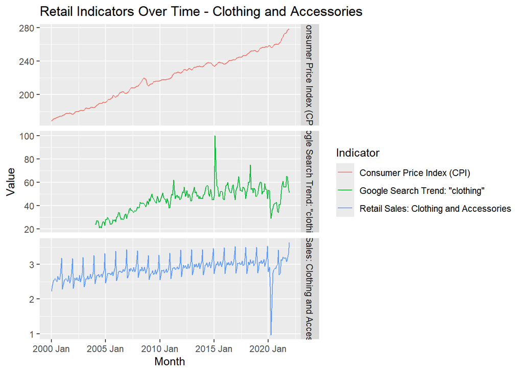

Google Trends for “clothing” shows seasonal spikes around holiday periods, with a noticeable dip during the 2020 pandemic and recovery afterward—mirroring temporary disruptions and shifts to online shopping behavior.

Retail Sales for Clothing and Accessories Stores display strong seasonality and a generally upward trend, with a sharp decline in 2020 due to COVID-19, followed by a recovery and continued growth post-pandemic.

#### Model Fitting

```
# A mable: 10 x 2
# Key:     Model name [10]
   `Model name`                                   Orders
   <chr>                                         <model>
 1 fourier6                                       <TSLM>
 2 ets                                      <ETS(A,A,A)>
 3 arima012011                 <ARIMA(0,1,2)(0,1,1)[12]>
 4 arima210011                 <ARIMA(2,1,0)(0,1,1)[12]>
 5 arima210110                 <ARIMA(2,1,0)(1,1,0)[12]>
 6 stepwise           <ARIMA(1,0,3)(0,1,2)[12] w/ drift>
 7 arima1             <ARIMA(3,0,0)(1,1,1)[12] w/ drift>
 8 arimax_cpi     <LM w/ ARIMA(1,0,3)(0,1,2)[12] errors>
 9 arimax_google  <LM w/ ARIMA(0,1,0)(1,0,0)[12] errors>
10 arima_fourier6            <LM w/ ARIMA(0,1,3) errors>
```

##### AIC Comparison

```
# A tibble: 10 × 6
   .model         sigma2 log_lik    AIC   AICc    BIC
   <chr>           <dbl>   <dbl>  <dbl>  <dbl>  <dbl>
 1 fourier6       0.0266   111.  -942.  -941.  -892.
 2 arima_fourier6 0.0138   197.  -362.  -360.  -305.
 3 arimax_cpi     0.0136   182.  -347.  -346.  -315.
 4 arima1         0.0139   179.  -343.  -343.  -318.
 5 stepwise       0.0140   179.  -341.  -340.  -313.
 6 arima012011    0.0153   163.  -318.  -318.  -304.
 7 arima210110    0.0158   159.  -310.  -310.  -296.
 8 arima210011    0.0160   158.  -308.  -308.  -294.
 9 arimax_google  0.0292    48.4  -90.8  -90.7  -80.1
10 ets            0.0181  -199.   431.   434.   492.
```

Overall, the fourier6 model demonstrated the strongest performance, effectively capturing seasonal variations. External regressors like CPI provided some additional predictive value, but Google Trends data did not significantly enhance model accuracy in the clothing sector.

###### Forecasts: Top 6 Models Ranked by AICc

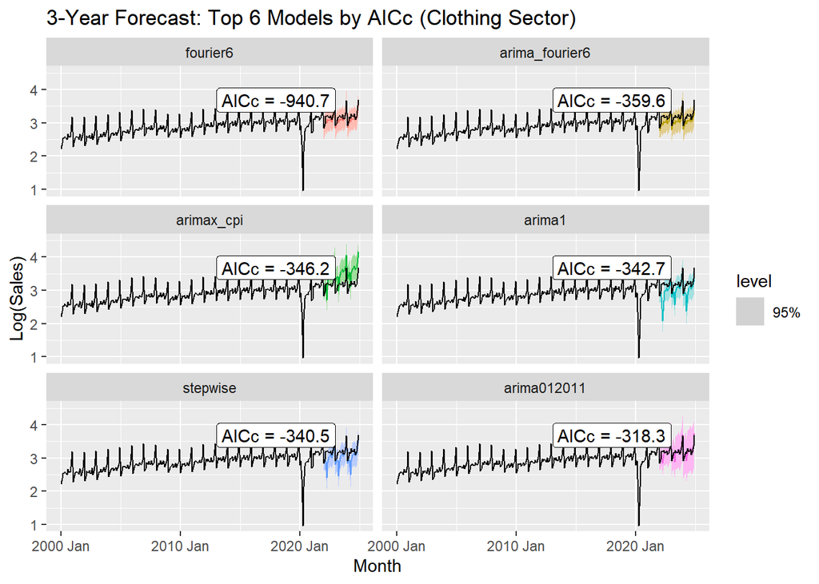

##### Training Data RMSE

```
# A tibble: 10 × 5
   .model         .type     RMSE    MAE  MAPE
   <chr>          <chr>    <dbl>  <dbl> <dbl>
 1 arimax_cpi     Training 0.112 0.0449  1.97
 2 arima1         Training 0.114 0.0457  2.01
 3 stepwise       Training 0.114 0.0443  1.96
 4 arima_fourier6 Training 0.114 0.0490  2.12
 5 arima012011    Training 0.120 0.0453  1.99
 6 arima210110    Training 0.122 0.0537  2.26
 7 arima210011    Training 0.123 0.0481  2.07
 8 ets            Training 0.131 0.0533  2.30
 9 fourier6       Training 0.159 0.0723  3.11
10 arimax_google  Training 0.188 0.0905  3.59
```

Overall, CPI proved to be a more effective external regressor for clothing sales than Google Trends, suggesting that macroeconomic indicators provide more predictive value for this sector.

###### Forecasts: Top 6 Models Ranked by Training Data RMSE

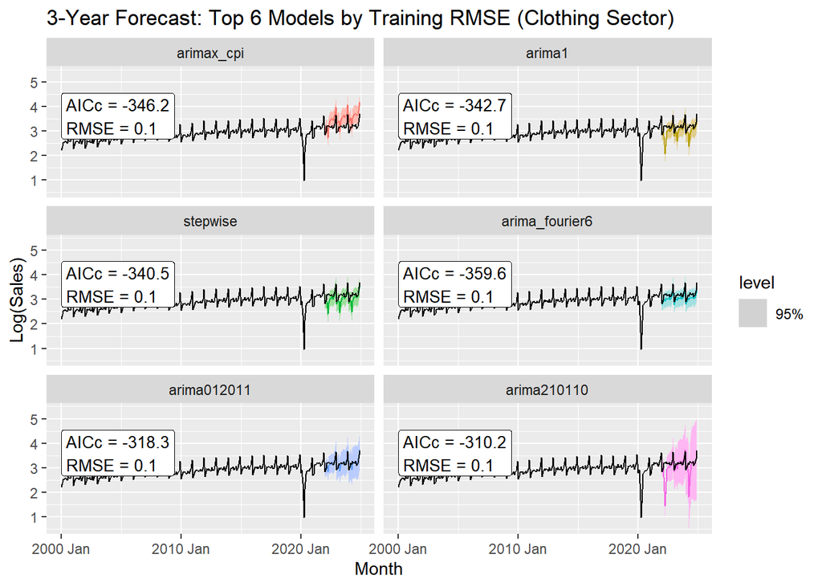

##### Test Data RMSE

```
# A tibble: 10 × 5
   .model         .type   RMSE    MAE  MAPE
   <chr>          <chr>  <dbl>  <dbl> <dbl>
 1 ets            Test  0.0515 0.0431  1.35
 2 fourier6       Test  0.0794 0.0677  2.13
 3 arima012011    Test  0.0954 0.0601  1.88
 4 arima210011    Test  0.0957 0.0570  1.79
 5 arima_fourier6 Test  0.131  0.124   3.90
 6 stepwise       Test  0.250  0.169   5.28
 7 arima1         Test  0.301  0.197   6.17
 8 arimax_google  Test  0.360  0.332  10.5
 9 arimax_cpi     Test  0.365  0.337  10.5
10 arima210110    Test  0.423  0.214   6.71
```

I evaluated model performance on the test set (2022–2024) using RMSE to assess generalization to unseen data for clothing retail sales:

- ETS emerged as the best performer with the lowest test RMSE (0.0515), capturing overall sales patterns without relying on external regressors, but it’s AIC is higher.
- Fourier6 also performed well (RMSE = 0.0794), suggesting that seasonal components are significant drivers in clothing retail sales.
- ARIMA models (arima012011 and arima210011) showed moderate performance with RMSEs around 0.095, indicating that basic ARIMA structures still hold predictive value.
- ARIMA + Fourier terms (arima_fourier6) had a higher RMSE (0.131), indicating that seasonality alone wasn’t sufficient to capture test data variability effectively.
- ARIMAX models (arimax_google and arimax_cpi) underperformed, with RMSEs of 0.360 and 0.365, respectively, suggesting that external signals like Google Trends and CPI did not align well with clothing sales in the test period.

Overall, simple ETS and Fourier models generalized better than ARIMA variants with external regressors, marking a departure from previous findings in the food services sector.

###### Forecasts: Top 6 Models Ranked by Test Data RMSE

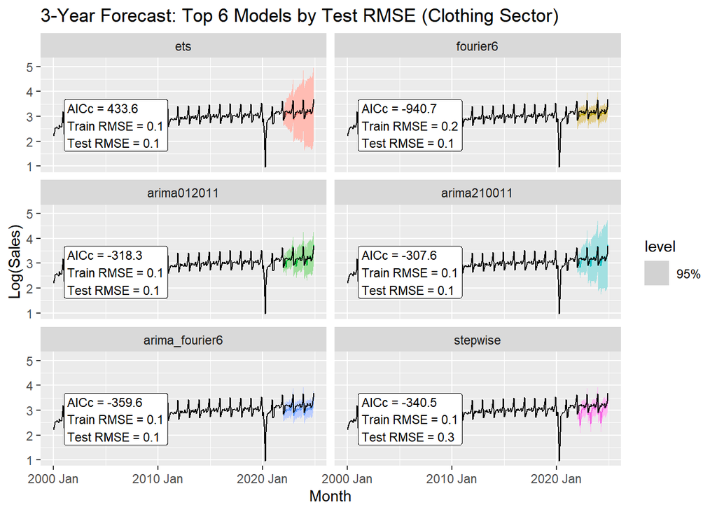